# Datasety

```python
import matplotlib.pyplot as plt
import seaborn as sns
import pandas as pd
import numpy as np
import scipy.stats as stats
import statsmodels.api as sm
import statsmodels.stats.api as sms
import scipy.stats as stats
from sklearn import preprocessing
from datetime import datetime
from datetime import date
```

```python
filename = "dataset/labor.csv"
labor = pd.read_csv(filename, sep='\t')
labor.head()
```

|  | Unnamed: 0 | etytr | indicator | alp | er-cv | leukocyty | hbver | alt | trombocyty | ast | weight | ssn | relationship | hematokrit | smoker | hemoglobin | erytrocyty | name |
| --- | --- | --- | --- | --- | --- | --- | --- | --- | --- | --- | --- | --- | --- | --- | --- | --- | --- | --- |
| 0 | 0 | 6.56611 | 0.0 | 71.34866 | 49.93293 | 4.01096 | 7.63611 | 16.53642 | 4.12686 | 62.82161 | 38.94182 | 613-31-7943 | married | 6.15761 | no | 7.24929 | 7.40249 | Terry Walker |
| 1 | 1 | 6.57510 | 0.0 | 73.19819 | 50.61146 | 7.36386 | 4.45735 | 12.41316 | 6.89853 | 64.10856 | 39.93677 | 071-29-7068 | widowed | 5.02794 | no | 7.41189 | 7.05999 | Christopher Mccall |
| 2 | 2 | 7.46203 | 1.0 | 12.80221 | 45.76702 | 7.86319 | 6.46036 | 7.75601 | 6.02906 | 62.88964 | 36.82128 | 465-01-6369 | married | 4.67262 | Y | 9.91113 | 5.59064 | Mrs. Alisha Jackson DVM |
| 3 | 3 | 5.15667 | 1.0 | 86.69531 | 41.73339 | 4.49672 | 3.99015 | 3.84333 | 6.71704 | 72.09725 | 64.70210 | 698-87-9617 | single | 6.40977 | Y | 6.55248 | 5.71480 | Crystal Dean |
| 4 | 4 | 4.25219 | 1.0 | 11.50857 | 43.33880 | 3.68340 | 8.19481 | 6.28617 | 6.51026 | 66.57561 | -3.98413 | 209-04-2399 | separated | 5.65006 | no | 3.15066 | 5.61537 | Joseph Garza |

```python
filename = "dataset/profiles.csv"
profiles = pd.read_csv(filename, sep='\t')
profiles.head()
```

|  | Unnamed: 0 | blood_group | job | sex | name | company | race | ssn | birthdate | current_location |
| --- | --- | --- | --- | --- | --- | --- | --- | --- | --- | --- |
| 0 | 0 | A- | Pension scheme manager | F | Megan Wells | Smith-Lawrence | Indian | 788-45-8299 | 08/15/1913, 00:00:00 | (Decimal('-2.7462585'), Decimal('-56.259761')) |
| 1 | 1 | AB+ | Psychotherapist, child | F | Barbara Patel | Oneal and Sons | Hawaiian | 291-49-5180 | 10/29/1905, 00:00:00 | (Decimal('-54.1724985'), Decimal('163.273340')) |
| 2 | 2 | B- | Engineer, drilling | F | Brianna Lane | Morris-Arnold | Asian | 146-49-1796 | 1980/05/13 | (Decimal('39.8342665'), Decimal('-54.720127')) |
| 3 | 3 | A- | Engineer, mining | M | William Cooper | Dunn LLC | White | 700-73-0733 | 1921-12-14 | (Decimal('-76.8352515'), Decimal('-0.539735')) |
| 4 | 4 | A+ | Restaurant manager | F | Holly Williams | Bailey-Sullivan | White | 748-70-9973 | 1924-12-30 | (Decimal('-59.667122'), Decimal('81.468274')) |

# Faza 1. Základný opis dát spolu s ich charakteristikami

- počet záznamov,
- počet atribútov,
- ich typy,
- pre zvolené významné atribúty ich distribúcie, základné deskriptívne štatistiky a pod.

```python
# number of records profiles
profiles.shape[0]
```

```
3123
```

```python
# number of records labor
labor.shape[0]
```

```
9976
```

```python
# number of atributes profiles
profiles.columns.size
```

```
10
```

```python
# number of atributes labor
labor.columns.size
```

```
18
```

```python
# types of atributes profiles
profiles.dtypes
```

```
Unnamed: 0           int64
blood_group         object
job                 object
sex                 object
name                object
company             object
race                object
ssn                 object
birthdate           object
current_location    object
dtype: object
```

```python
# types of atributes labor
labor.dtypes
```

```
Unnamed: 0        int64
etytr           float64
indicator       float64
alp             float64
er-cv           float64
leukocyty       float64
hbver           float64
alt             float64
trombocyty      float64
ast             float64
weight          float64
ssn              object
relationship     object
hematokrit      float64
smoker           object
hemoglobin      float64
erytrocyty      float64
name             object
dtype: object
```

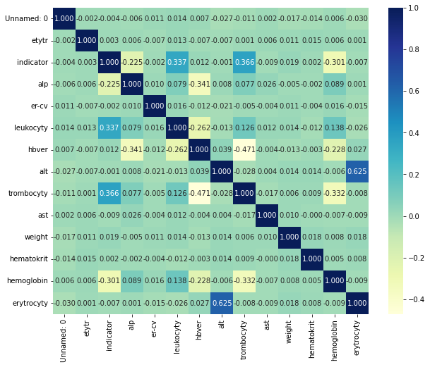

```python
# Correlations heatmap
fig, ax = plt.subplots(figsize=(10,8))
sns.heatmap(labor.corr(), ax=ax,cmap="YlGnBu", annot=True, fmt=".3f")
```

```python
labor[['hemoglobin', 'hbver', 'trombocyty', 'leukocyty', 'alt', 'erytrocyty']].describe()
```

|  | hemoglobin | hbver | trombocyty | leukocyty | alt | erytrocyty |
| --- | --- | --- | --- | --- | --- | --- |
| count | 9946.000000 | 9946.000000 | 9946.000000 | 9946.000000 | 9946.000000 | 9945.000000 |
| mean | 6.200070 | 5.783637 | 6.584805 | 5.396771 | 9.167064 | 5.798073 |
| std | 1.705544 | 1.682270 | 1.471984 | 1.549857 | 3.934239 | 1.006324 |
| min | 0.810320 | 0.465590 | 0.967360 | 0.000000 | 0.000000 | 1.599500 |
| 25% | 4.925607 | 4.552373 | 5.644348 | 4.279130 | 6.836913 | 5.130850 |
| 50% | 6.222180 | 5.928270 | 6.708440 | 5.185765 | 8.660790 | 5.800240 |
| 75% | 7.421258 | 7.065975 | 7.569437 | 6.421222 | 10.754530 | 6.470690 |
| max | 12.119600 | 11.636340 | 11.911000 | 11.345060 | 100.000000 | 9.950430 |

```python
labor[['hemoglobin', 'hbver', 'trombocyty', 'leukocyty', 'alt', 'erytrocyty']].median()
```

```
hemoglobin    6.222180
hbver         5.928270
trombocyty    6.708440
leukocyty     5.185765
alt           8.660790
erytrocyty    5.800240
dtype: float64
```

```python
labor[['hemoglobin', 'hbver', 'trombocyty', 'leukocyty', 'alt', 'erytrocyty']].skew()
```

```
hemoglobin    0.045604
hbver        -0.255204
trombocyty   -0.230527
leukocyty     0.389468
alt           3.683199
erytrocyty    0.010909
dtype: float64
```

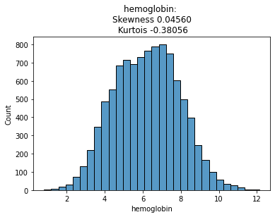

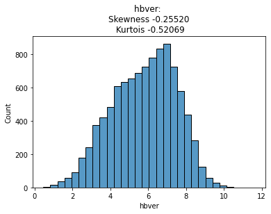

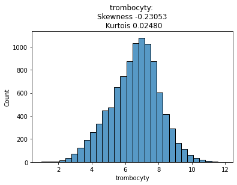

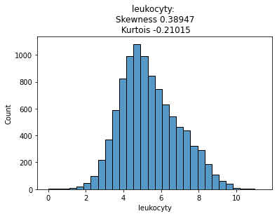

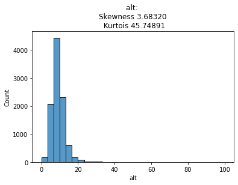

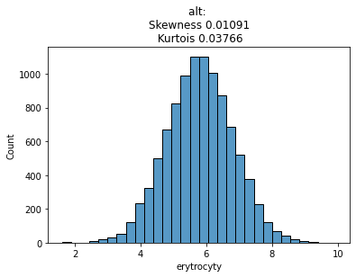

```python
sns.histplot(labor.hemoglobin, bins=30)
plt.title("hemoglobin: \n""Skewness %.5f\n Kurtois %.5f" % (labor.hemoglobin.skew(), labor.hemoglobin.kurtosis()))
plt.show()

sns.histplot(labor.hbver, bins=30)
plt.title("hbver: \n""Skewness %.5f\n Kurtois %.5f" % (labor.hbver.skew(), labor.hbver.kurtosis()))

plt.show()

sns.histplot(labor.trombocyty, bins=30)
plt.title("trombocyty: \n""Skewness %.5f\n Kurtois %.5f" % (labor.trombocyty.skew(), labor.trombocyty.kurtosis()))
plt.show()

sns.histplot(labor.leukocyty, bins=30)
plt.title("leukocyty: \n""Skewness %.5f\n Kurtois %.5f" % (labor.leukocyty.skew(), labor.leukocyty.kurtosis()))
plt.show()

sns.histplot(labor.alt, bins=30)
plt.title("alt: \n""Skewness %.5f\n Kurtois %.5f" % (labor.alt.skew(), labor.alt.kurtosis()))
plt.show()

sns.histplot(labor.erytrocyty, bins=30)
plt.title("alt: \n""Skewness %.5f\n Kurtois %.5f" % (labor.erytrocyty.skew(), labor.erytrocyty.kurtosis()))
plt.show()
```

# 2. Párová analýza

- Preskúmajte vzťahy medzi zvolenými dvojicami atribútov.
- Identifikujte závislostí medzi dvojicami atribútov a závislosti medzi predikovanou premennou a ostatnými premennými.

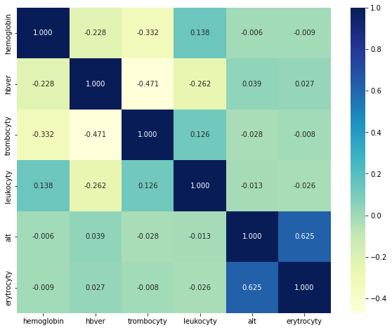

```python
# Correlations heatmap
fig, ax = plt.subplots(figsize=(10,8))
sns.heatmap(labor[['hemoglobin', 'hbver', 'trombocyty', 'leukocyty', 'alt', 'erytrocyty']].corr(), ax=ax,cmap="YlGnBu", annot=True, fmt=".3f")
```

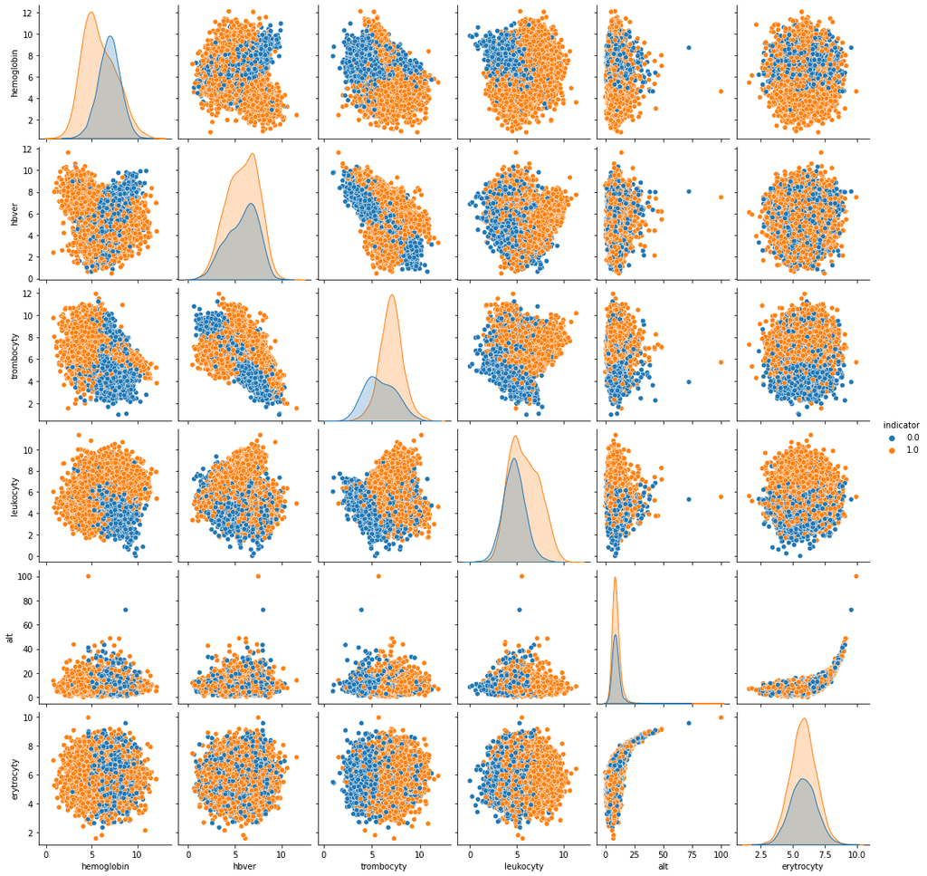

```python
sns.pairplot(labor[['hemoglobin', 'hbver', 'trombocyty', 'leukocyty', 'alt', 'indicator', 'erytrocyty']], hue='indicator')
```

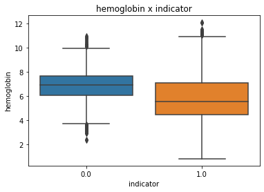

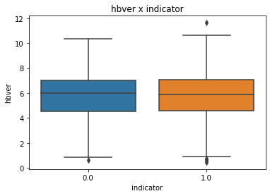

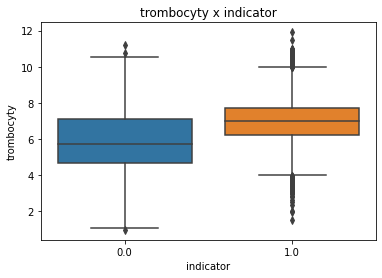

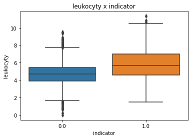

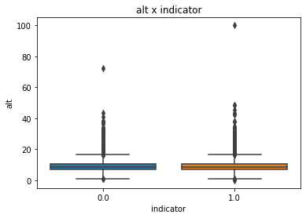

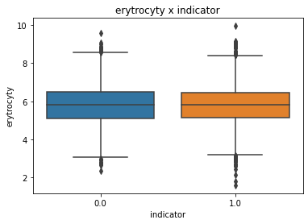

```python
for attr in ['hemoglobin', 'hbver', 'trombocyty', 'leukocyty', 'alt', 'erytrocyty']:
    sns.boxplot(data=labor, x='indicator', y=attr)
    plt.title(attr + ' x indicator')
    plt.show()
```

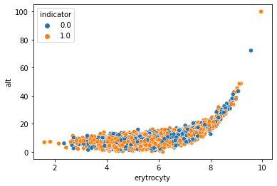

```python
sns.scatterplot(x='erytrocyty',  y='alt', data=labor,hue='indicator')
```

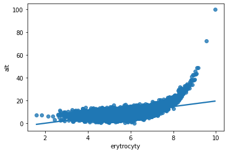

```python
sns.regplot(x="erytrocyty", y="alt", data=labor)
```

```python
labor['erytrocyty'].corr(labor['alt'])
```

```
0.6249049735041573
```

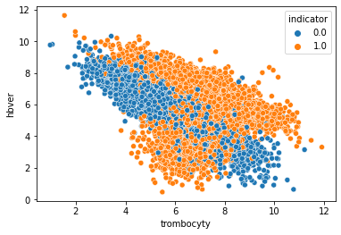

```python
sns.scatterplot(x='trombocyty',  y='hbver', data=labor, hue='indicator')
```

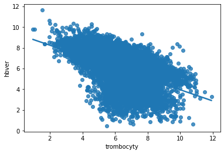

```python
sns.regplot(x="trombocyty", y="hbver", data=labor)
```

```python
labor['trombocyty'].corr(labor['hbver'])
```

```
-0.47085262414364143
```

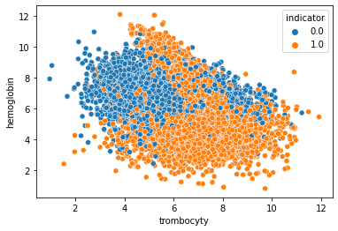

```python
sns.scatterplot(x='trombocyty',  y='hemoglobin', data=labor,hue='indicator')
```

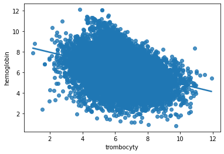

```python
sns.regplot(x="trombocyty", y="hemoglobin", data=labor)
```

```python
labor['trombocyty'].corr(labor['hemoglobin'])
```

```
-0.3322056174220032
```

# 3. Formulácia a štatistické overenie hypotéz o dátach (2 body)

- Sformulujte dve hypotézy o dátach v kontexte zadanej predikčnej úlohy. Príkladom je napr. pacienti v zlepšenom stave majú v priemere inú (vyššiu/nižšiu) hodnotu nejakej látky alebo hormónu ako pacienti v nezlepšenom stave.
- Sformulované hypotézy overte vhodne zvoleným štatistickým testom.

## Hypotéza 1

*H0*: Hodnota hemoglobínu zdravých pacientov je v priemere rovnaká ako u chorých pacientov. *HA*: Hodnota hemoglobínu zdravých pacientov je v priemere vyššia/nižšia ako u chorých pacientov.

```python
healthy = labor.loc[labor.indicator == 0, 'hemoglobin'].dropna()
```

```python
healthy.describe()
```

```
count    3562.000000
mean        6.887613
std         1.217612
min         2.368140
25%         6.090463
50%         6.913745
75%         7.689430
max        10.978090
Name: hemoglobin, dtype: float64
```

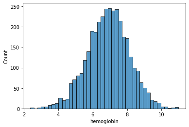

```python
sns.histplot(healthy)
```

```python
def identify_outliers(a):
    lower = a.quantile(0.25) - 1.5 * stats.iqr(a)
    upper = a.quantile(0.75) + 1.5 * stats.iqr(a)
    return a[(a > upper) | (a < lower)]
```

```python
healthy_out = identify_outliers(healthy)
healthy_out
```

```
439     10.61623
482      2.89968
816     10.46731
1115    10.27534
1468     3.59432
1634     3.65550
1877    10.11474
2331     3.61415
2367     2.36814
2808     3.50878
3669    10.97809
3735    10.11834
3786    10.18691
3847     2.43278
4035     3.08637
```

[output cut: 23 more lines]

```python
healthy = healthy.drop(healthy_out.index)
```

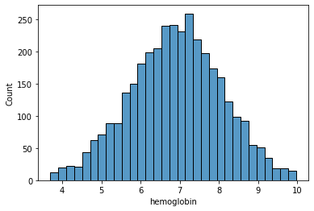

```python
sns.histplot(healthy)
```

```python
test_frame = labor.sample(n=4500)
unhealthy = test_frame.loc[test_frame.indicator == 1, 'hemoglobin'].dropna()
```

```python
unhealthy.describe()
```

```
count    2866.000000
mean        5.837639
std         1.815791
min         0.906140
25%         4.485020
50%         5.572985
75%         7.118405
max        12.066440
Name: hemoglobin, dtype: float64
```

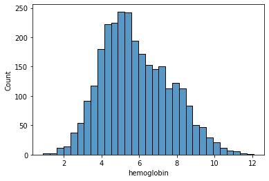

```python
sns.histplot(unhealthy)
```

```python
unhealthy_out = identify_outliers(unhealthy)
unhealthy_out
```

```
5020    12.06644
6291    11.07796
4679    11.44840
3806    11.14014
9834    11.11818
4758    11.36692
4159    11.13085
Name: hemoglobin, dtype: float64
```

```python
unhealthy = unhealthy.drop(unhealthy_out.index)
```

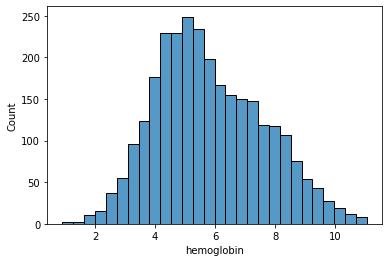

```python
sns.histplot(unhealthy)
```

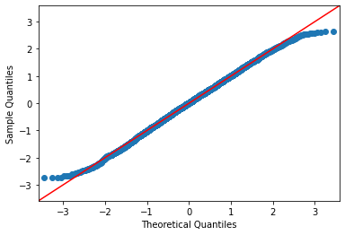

```python
_ = sm.ProbPlot(healthy, fit=True).qqplot(line='45')
```

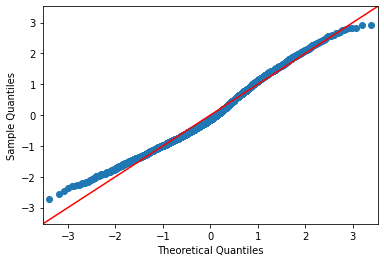

```python
_ = sm.ProbPlot(unhealthy, fit=True).qqplot(line='45')
```

Shapiro-Willkov test normálnosti

```python
stats.shapiro(healthy)
```

```
ShapiroResult(statistic=0.9978073835372925, pvalue=6.922722241142765e-05)
```

```python
stats.shapiro(unhealthy)
```

```
ShapiroResult(statistic=0.985218346118927, pvalue=1.0741292963814257e-16)
```

Podľa Shapiro-willkov testu normálnosti zamietne nulovú hypotézu a dáta nepochádzajú z normálneho rozdelenia

```python
stats.levene(healthy, unhealthy)
```

```
LeveneResult(statistic=561.2781649932472, pvalue=5.364023947498879e-119)
```

```python
stats.mannwhitneyu(healthy, unhealthy)
```

```
MannwhitneyuResult(statistic=7025414.0, pvalue=4.777691542871416e-162)
```

Keďže chyba prvého rádu je menšie ako 1 promile, tak zamietame našu nulovú hypotézu v prospech alternatívnej hypotézy

```python
sms.DescrStatsW(healthy).tconfint_mean()
```

```
(6.860643920100708, 6.937683092665248)
```

```python
sms.DescrStatsW(unhealthy).tconfint_mean()
```

```
(5.7582648292408924, 5.8900914351872276)
```

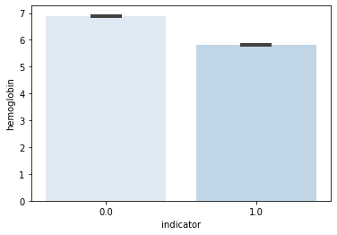

```python
sns.barplot(x='indicator', y='hemoglobin', data=labor[(labor.indicator==0)|(labor.indicator==1)],capsize=0.2, errwidth=2, palette=sns.color_palette("Blues"))
```

Aj podľa grafov vidíme, že hodnota hemoglobínu u zdravých pacientov je priemerne vyššia ako hodnota hemoglobínu u chorých pacientov.